# Maternal Microbiome

Introduction:

Our dataset contains levels of gut bacteria in healthy and unhealthy pregnant women. In this project, we are trying to find “candidate” bacteria -> bacteria that likely contributes to the health of the sample, so we can zero in on what might be causing illness.

Reading & Cleaning Data:

- This data contains 7 healthy and 7 unhealthy samples from maternal microbiomes
- To clean the data, we will remove the column containing averages for each bacteria and merge the first three columns into row names that contain the names for each bacteria

```r
my_data<- read.csv("./maternalmicrobiome.csv", header=TRUE)
my_data<- my_data[,1:17]
head(my_data)
```

|  | X | X.1 | X.2 | Healthy.T2.004 | Healthy.T2.010 | Healthy.T3.014 | Healthy.T3.015 | Healthy.T3.017 | Healthy.T3.019 | Healthy.T2.033 | Unhealthy.T2.012 | Unhealthy.T3.018 | Unhealthy.T3.022 | Unhealthy.T3.044 | Unhealthy.T3.051 | Unhealthy.T3.052 | Unhealthy.T3.053 |
| --- | --- | --- | --- | --- | --- | --- | --- | --- | --- | --- | --- | --- | --- | --- | --- | --- | --- |
| 1 | Actinomycetaceae;g | Actinomyces;s | odontolyticus | 0.0001934985 | 0.0001854835 | 0.0007030958 | 0.00000000 | 0.0003603171 | 0.000000000 | 0.0004470701 | 0.0001556178 | 0 | 0 | 0.0001828942 | 0.0002372999 | 0.0004031355 | 0 |
| 2 | Actinomycetaceae;g | Actinomyces;s | oris | 0.0000000000 | 0.0000000000 | 0.0000000000 | 0.00000000 | 0.0000000000 | 0.000000000 | 0.0003619139 | 0.0000000000 | 0 | 0 | 0.0000000000 | 0.0000000000 | 0.0000000000 | 0 |
| 3 | Actinomycetaceae;g | NA;s | sp4816 | 0.0000000000 | 0.0000000000 | 0.0000000000 | 0.00000000 | 0.0000000000 | 0.000000000 | 0.0001277343 | 0.0000000000 | 0 | 0 | 0.0000000000 | 0.0000000000 | 0.0000000000 | 0 |
| 4 | Bifidobacteriaceae;g | Bifidobacterium;s | adolescentis-faecale | 0.0000000000 | 0.0687655587 | 0.0000000000 | 0.00000000 | 0.0016214269 | 0.001898469 | 0.0000000000 | 0.0000000000 | 0 | 0 | 0.0000000000 | 0.0137451399 | 0.0000000000 | 0 |
| 5 | Bifidobacteriaceae;g | Bifidobacterium;s | animalis | 0.0000000000 | 0.0000000000 | 0.0000000000 | 0.01546268 | 0.0000000000 | 0.000000000 | 0.0000000000 | 0.0000000000 | 0 | 0 | 0.0000000000 | 0.0000000000 | 0.0000000000 | 0 |
| 6 | Bifidobacteriaceae;g | Bifidobacterium;s | bifidum | 0.0000000000 | 0.0000000000 | 0.0000000000 | 0.00000000 | 0.0226999760 | 0.000000000 | 0.0000000000 | 0.0000000000 | 0 | 0 | 0.0000000000 | 0.0000000000 | 0.0000000000 | 0 |

```r
sub_data<- my_data[, 1:3]
row_names<-apply(sub_data, 1, function(r){paste(r[1], r[2], r[3], sep="_")})
row.names(my_data)<- row_names
my_data<- my_data[,-c(1, 2, 3)]
head(my_data)
```

|  | Healthy.T2.004 | Healthy.T2.010 | Healthy.T3.014 | Healthy.T3.015 | Healthy.T3.017 | Healthy.T3.019 | Healthy.T2.033 | Unhealthy.T2.012 | Unhealthy.T3.018 | Unhealthy.T3.022 | Unhealthy.T3.044 | Unhealthy.T3.051 | Unhealthy.T3.052 | Unhealthy.T3.053 |
| --- | --- | --- | --- | --- | --- | --- | --- | --- | --- | --- | --- | --- | --- | --- |
| Actinomycetaceae;g_Actinomyces;s_odontolyticus | 0.0001934985 | 0.0001854835 | 0.0007030958 | 0.00000000 | 0.0003603171 | 0.000000000 | 0.0004470701 | 0.0001556178 | 0 | 0 | 0.0001828942 | 0.0002372999 | 0.0004031355 | 0 |
| Actinomycetaceae;g_Actinomyces;s_oris | 0.0000000000 | 0.0000000000 | 0.0000000000 | 0.00000000 | 0.0000000000 | 0.000000000 | 0.0003619139 | 0.0000000000 | 0 | 0 | 0.0000000000 | 0.0000000000 | 0.0000000000 | 0 |
| Actinomycetaceae;g_NA;s_sp4816 | 0.0000000000 | 0.0000000000 | 0.0000000000 | 0.00000000 | 0.0000000000 | 0.000000000 | 0.0001277343 | 0.0000000000 | 0 | 0 | 0.0000000000 | 0.0000000000 | 0.0000000000 | 0 |
| Bifidobacteriaceae;g_Bifidobacterium;s_adolescentis-faecale | 0.0000000000 | 0.0687655587 | 0.0000000000 | 0.00000000 | 0.0016214269 | 0.001898469 | 0.0000000000 | 0.0000000000 | 0 | 0 | 0.0000000000 | 0.0137451399 | 0.0000000000 | 0 |
| Bifidobacteriaceae;g_Bifidobacterium;s_animalis | 0.0000000000 | 0.0000000000 | 0.0000000000 | 0.01546268 | 0.0000000000 | 0.000000000 | 0.0000000000 | 0.0000000000 | 0 | 0 | 0.0000000000 | 0.0000000000 | 0.0000000000 | 0 |
| Bifidobacteriaceae;g_Bifidobacterium;s_bifidum | 0.0000000000 | 0.0000000000 | 0.0000000000 | 0.00000000 | 0.0226999760 | 0.000000000 | 0.0000000000 | 0.0000000000 | 0 | 0 | 0.0000000000 | 0.0000000000 | 0.0000000000 | 0 |

Reformatting Data

```r
transposed_data<- data.frame(t(my_data))
head(transposed_data)
```

|  | Actinomycetaceae.g_Actinomyces.s_odontolyticus | Actinomycetaceae.g_Actinomyces.s_oris | Actinomycetaceae.g_NA.s_sp4816 | Bifidobacteriaceae.g_Bifidobacterium.s_adolescentis.faecale | Bifidobacteriaceae.g_Bifidobacterium.s_animalis | Bifidobacteriaceae.g_Bifidobacterium.s_bifidum | Bifidobacteriaceae.g_Bifidobacterium.s_breve | Bifidobacteriaceae.g_Bifidobacterium.s_catenulatum.kashiwanohense.pseudocatenulatum | Bifidobacteriaceae.g_Bifidobacterium.s_longum | Bifidobacteriaceae.g_Bifidobacterium.s_pseudolongum | Corynebacteriaceae.g_Corynebacterium.s_appendicis | Micrococcaceae.g_Rothia.s_mucilaginosa | Propionibacteriaceae.g_Propionibacterium.s_acnes | Coriobacteriaceae.g_Adlercreutzia.Asaccharobacter.s_celatus.equolifaciens | Coriobacteriaceae.g_Collinsella.s_aerofaciens | Coriobacteriaceae.g_Collinsella.s_intestinalis.stercoris | Coriobacteriaceae.g_Collinsella.s_sp10410 | Coriobacteriaceae.g_Collinsella.s_sp10422 | Coriobacteriaceae.g_Collinsella.s_sp10425 | Coriobacteriaceae.g_Collinsella.s_tanakaei | Coriobacteriaceae.g_Denitrobacterium.s_detoxificans.sp10543 | Coriobacteriaceae.g_Eggerthella.s_lenta | Coriobacteriaceae.g_Eggerthella.s_sinensis | Coriobacteriaceae.g_Enterorhabdus.s_caecimuris | Coriobacteriaceae.g_Enterorhabdus.s_caecimuris.mucosicola | Coriobacteriaceae.g_Gordonibacter.s_faecihominis | Coriobacteriaceae.g_Gordonibacter.s_pamelaeae | Coriobacteriaceae.g_NA.s_sp10501 | Coriobacteriaceae.g_NA.s_sp10534 | … |
| --- | --- | --- | --- | --- | --- | --- | --- | --- | --- | --- | --- | --- | --- | --- | --- | --- | --- | --- | --- | --- | --- | --- | --- | --- | --- | --- | --- | --- | --- | --- |
| Healthy.T2.004 | 0.0001934985 | 0 | 0 | 0.000000000 | 0.00000000 | 0.00000000 | 0 | 0.000000000 | 0.11815499 | 0 | 0.0000000000 | 0.0000000000 | 0.0000000000 | 0.000000000 | 0.00000000 | 0 | 0.0000000000 | 0 | 0.0000000000 | 0.000000000 | 0 | 0.0000000000 | 0 | 0.0000000000 | 0 | 0.0003386223 | 0 | 0.000000000 | 0 | … |
| Healthy.T2.010 | 0.0001854835 | 0 | 0 | 0.068765559 | 0.00000000 | 0.00000000 | 0 | 0.015033924 | 0.01680090 | 0 | 0.0000000000 | 0.0001757212 | 0.0002147703 | 0.001015278 | 0.04011324 | 0 | 0.0000000000 | 0 | 0.0000000000 | 0.003367989 | 0 | 0.0000000000 | 0 | 0.0003319178 | 0 | 0.0000000000 | 0 | 0.002059843 | 0 | … |
| Healthy.T3.014 | 0.0007030958 | 0 | 0 | 0.000000000 | 0.00000000 | 0.00000000 | 0 | 0.000000000 | 0.01160108 | 0 | 0.0003076044 | 0.0002636609 | 0.0000000000 | 0.000000000 | 0.01667655 | 0 | 0.0000000000 | 0 | 0.0000000000 | 0.000000000 | 0 | 0.0021971744 | 0 | 0.0000000000 | 0 | 0.0000000000 | 0 | 0.000000000 | 0 | … |
| Healthy.T3.015 | 0.0000000000 | 0 | 0 | 0.000000000 | 0.01546268 | 0.00000000 | 0 | 0.000262450 | 0.00000000 | 0 | 0.0002405791 | 0.0000000000 | 0.0000000000 | 0.000000000 | 0.00000000 | 0 | 0.0000000000 | 0 | 0.0000000000 | 0.000000000 | 0 | 0.0088139448 | 0 | 0.0000000000 | 0 | 0.0000000000 | 0 | 0.000000000 | 0 | … |
| Healthy.T3.017 | 0.0003603171 | 0 | 0 | 0.001621427 | 0.00000000 | 0.02269998 | 0 | 0.009098006 | 0.01336176 | 0 | 0.0000000000 | 0.0000000000 | 0.0000000000 | 0.001531348 | 0.03936464 | 0 | 0.0008407399 | 0 | 0.0000000000 | 0.003933461 | 0 | 0.0003302907 | 0 | 0.0000000000 | 0 | 0.0000000000 | 0 | 0.001261110 | 0 | … |
| Healthy.T3.019 | 0.0000000000 | 0 | 0 | 0.001898469 | 0.00000000 | 0.00000000 | 0 | 0.133580483 | 0.09776369 | 0 | 0.0000000000 | 0.0000000000 | 0.0000000000 | 0.000000000 | 0.02303576 | 0 | 0.0000000000 | 0 | 0.0003139201 | 0.000000000 | 0 | 0.0054711791 | 0 | 0.0000000000 | 0 | 0.0000000000 | 0 | 0.000000000 | 0 | … |

Finding candidates out of bacteria:

- We will use two sample t-tests to identify which bacteria are potential candidates, by looking at the bacteria with the most obvious difference in healthy and unhealthy samples
- The p-value is the probability that the differences in bacteria levels in these two groups are due to sampling errors
- The lower the p-value, the more likely the bacteria is a candidate

```r
candidates<- c()
significance_level<- 0.05
valid_p_values<- c()
for(i in 1:ncol(transposed_data)){
  healthy<-sapply(transposed_data[1:7, i], as.numeric)
  unhealthy<-sapply(transposed_data[8:14, i], as.numeric)
  results<- stats::t.test(healthy, unhealthy)
  if(results$p.value<=significance_level){
    candidates<- c(candidates, colnames(transposed_data)[i])
    valid_p_values<- c(valid_p_values, results$p.value)
  }
}
candidates
```

```
[1] "Streptococcaceae.g_Streptococcus.s_anginosus" "Lachnospiraceae.g_Blautia.s_wexlerae"         "Lachnospiraceae.g_Dorea.s_formicigenerans"
```

```r
valid_p_values
```

```
[1] 0.04231589 0.02294824 0.01979332
```

With Bonferoni Correction:

```r
candidates_bon<- c()
significance_level_bon<- 0.05
valid_p_values_bon<- c()
for(i in 1:ncol(transposed_data)){
  healthy<-sapply(transposed_data[1:7, i], as.numeric)
  unhealthy<-sapply(transposed_data[8:14, i], as.numeric)
  results<- stats::t.test(healthy, unhealthy)
  significance_level_bon<-significance_level_bon/i
  if(results$p.value<=significance_level_bon){
    candidates_bon<- c(candidates_bon, colnames(transposed_data)[i])
    valid_p_values_bon<- c(valid_p_values_bon, results$p.value)
  }
}
candidates_bon
```

[output not shown]

```r
valid_p_values_bon
```

FDR Correction:

```r
significance_level<- 0.2
fdr_bacteria<-c()
fdr_p_vals<- c()
for(i in 1:ncol(transposed_data)){
  healthy<-sapply(transposed_data[1:7, i], as.numeric)
  unhealthy<-sapply(transposed_data[8:14, i], as.numeric)
  results<- stats::t.test(healthy, unhealthy)
  fdr_bacteria<- c(fdr_bacteria, colnames(transposed_data)[i])
  fdr_p_vals<- c(fdr_p_vals, results$p.value)
}
m<- data.frame(fdr_bacteria, fdr_p_vals, p.adjust(fdr_p_vals, "fdr"), p.adjust(fdr_p_vals, "bonferroni"))
names(m) <- c("bacteria_name", "p_values", "fdr_corrected_p_values", "bonferroni_corrected_p_values")

m[m[fdr_corrected_p_values]<0.05, ]
```

| bacteria_name | p_values | fdr_corrected_p_values | bonferroni_corrected_p_values |
| --- | --- | --- | --- |

Summary:

- There are 3 bacteria with unadjusted p values less than are significance level of 0.05
- After adjusting the p values using bonferroni correction and fdr correction, there are no bacteria that still have adjusted p values under the significance level
- Our correction methods are too aggressive for our data

Assembling Data:

- The dataframe “m” contains the unadjusted p value, fdr corrected p value, and bonferroni corrected p value for each bacteria

```r
attach(m)
m<- m[order(p_values),]
m[1:30,]
```

|  | bacteria_name | p_values | fdr_corrected_p_values | bonferroni_corrected_p_values |
| --- | --- | --- | --- | --- |
| 183 | Lachnospiraceae.g_Dorea.s_formicigenerans | 0.01979332 | 0.5461294 | 1 |
| 179 | Lachnospiraceae.g_Blautia.s_wexlerae | 0.02294824 | 0.5461294 | 1 |
| 119 | Streptococcaceae.g_Streptococcus.s_anginosus | 0.04231589 | 0.5461294 | 1 |
| 403 | Erysipelotrichaceae.g_Erysipelatoclostridium.s_sp36616 | 0.05413772 | 0.5461294 | 1 |
| 213 | Lachnospiraceae.g_Lachnoclostridium.s_sp32428 | 0.07835387 | 0.5461294 | 1 |
| 309 | Peptostreptococcaceae.g_Intestinibacter.s_bartlettii | 0.08837438 | 0.5461294 | 1 |
| 342 | Ruminococcaceae.g_NA.s_sp35036 | 0.09460602 | 0.5461294 | 1 |
| 221 | Lachnospiraceae.g_Lachnoclostridium.s_sp32444 | 0.10549967 | 0.5461294 | 1 |
| 394 | Ruminococcaceae.g_Ruminiclostridium.s_sp34950 | 0.10835435 | 0.5461294 | 1 |
| 242 | Lachnospiraceae.g_NA.s_sp32660 | 0.10906848 | 0.5461294 | 1 |

[output cut: 20 more lines]

Graphing Data

```r
plot_bacteria <- function(bacteria){
  boxplot(transposed_data[1:7, bacteria], transposed_data[8:14, bacteria], main=paste(bacteria), col=c("green", "red"), names=c("healthy", "unhealthy"), cex.main=0.7)
}
par(mfrow=c(2, 2))
plot_bacteria(m[1,1])
plot_bacteria(m[2,1])
```

[figure not shown]

```r
plot_bacteria(m[3,1])
plot_bacteria(m[4,1])
```

```r
pdf("Test.pdf")
par(mfrow=c(4, 2))
top_7 <- m[1:7, 1]
for (i in 1:7){
  plot_bacteria(top_7[i])
}
graphics.off()
```

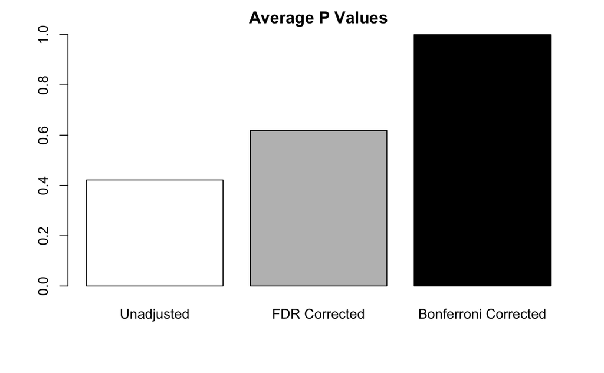

```r
barplot(sapply(m[, 2:4], mean), main="Average P Values", names.arg = c("Unadjusted", "FDR Corrected", "Bonferroni Corrected"), col=c("white", "grey", "black"))
```

Making an XGBoost Model:

- None of the bacteria had significant p-values, so our next step is using XGBoost to identify candidate bacteria
- xgboost stands for extreme gradient boosting, which is an ensemble learner that uses gradient boosting
- the gradient minimizes the loss from each model, and boosting is used to allow models to learn from the mistakes of previous models
- We’ll use xgboost to make a model that receives a sample and predicts whether it is healthy or unhealthy based on its bacteria levels
- The important features of the model will reveal which bacteria are the strongest indicators of whether or not the sample is healthy
- Max.depth = 4
- eta = 1
- nrounds = 3
- objective = “binary:logistic”

https://www.r-bloggers.com/2018/05/tuning-xgboost-in-r-part-i/ https://www.analyticsvidhya.com/blog/2016/03/complete-guide-parameter-tuning-xgboost-with-codes-python/

```r
labels<- c(1, 1, 1, 1, 1, 1, 1, 0, 0, 0, 0, 0, 0, 0)
my_data<- transposed_data
mod <- xgboost(data=as.matrix(my_data), label=labels, max.depth=4, eta=1, nrounds=3,  objective = "binary:logistic")
```

```
[22:38:34] INFO: amalgamation/../src/tree/updater_prune.cc:101: tree pruning end, 4 extra nodes, 0 pruned nodes, max_depth=2
[22:38:34] WARNING: amalgamation/../src/learner.cc:1095: Starting in XGBoost 1.3.0, the default evaluation metric used with the objective 'binary:logistic' was changed from 'error' to 'logloss'. Explicitly set eval_metric if you'd like to restore the old behavior.
[22:38:34] INFO: amalgamation/../src/tree/updater_prune.cc:101: tree pruning end, 2 extra nodes, 0 pruned nodes, max_depth=1
[22:38:34] INFO: amalgamation/../src/tree/updater_prune.cc:101: tree pruning end, 2 extra nodes, 0 pruned nodes, max_depth=1
```

Now we can look at which features (bacteria) our model is labelling as important

```r
importance<- xgb.importance(model = mod)
print(importance)
```

| Feature | Gain | Cover | Frequency |
| --- | --- | --- | --- |
| Bacteroidaceae.g_Bacteroides.s_massiliensis | 0.50080067 | 0.3202023 | 0.25 |
| Lachnospiraceae.g_Dorea.s_formicigenerans | 0.26620163 | 0.2619496 | 0.25 |
| Bacteroidaceae.g_Bacteroides.s_sp12288.thetaiotaomicron | 0.14194303 | 0.2120037 | 0.25 |
| Actinomycetaceae.g_Actinomyces.s_odontolyticus | 0.09105467 | 0.2058443 | 0.25 |

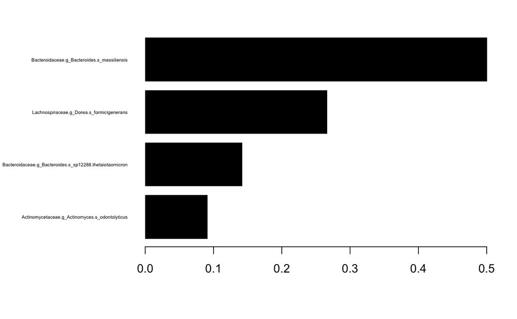

```r
xgb.plot.importance(importance_matrix = importance, col="black", cex=0.4)
```

```r
pdf("SignificantBacteria.pdf")
par(mfrow=c(5, 2))
top_7 <- m[1:7, 1]
for (i in 1:7){
  plot_bacteria(top_7[i])
}
plot_bacteria(importance[1, Feature])
```

```r
#plot_bacteria(importance[2, Feature])
plot_bacteria(importance[3, Feature])
plot_bacteria(importance[4, Feature])
```

```r
graphics.off()
```

We can use clustering to determine whether or not the important features found by our model are able to separate healthy from unhealthy samples

We will use K Means clustering and hierarichical clustering.

When using K means clustering, we are able to specify that we want the variables to separate our data into 2 clusters, which in our case is healthy and unhealthy

```r
xgb_bacteria <- as.matrix(transposed_data[, importance[,Feature]])
#xgb_bacteria<- t(xgb_bacteria)
```

```r
fit<- kmeans(xgb_bacteria, 2)
fit$cluster
```

```
  Healthy.T2.004   Healthy.T2.010   Healthy.T3.014   Healthy.T3.015   Healthy.T3.017   Healthy.T3.019   Healthy.T2.033 Unhealthy.T2.012
               1                1                1                1                1                1                1                1
Unhealthy.T3.018 Unhealthy.T3.022 Unhealthy.T3.044 Unhealthy.T3.051 Unhealthy.T3.052 Unhealthy.T3.053
               1                1                1                1                2                2
```

From the labels above, we can see that the kmeans clustering algorithm formed one cluster made up of 2 unhealthy samples, and another cluster made up of the rest.

This indicates that the features our model labelled at important do not perform strongly in distinguishing healthy from unhealthy samples.

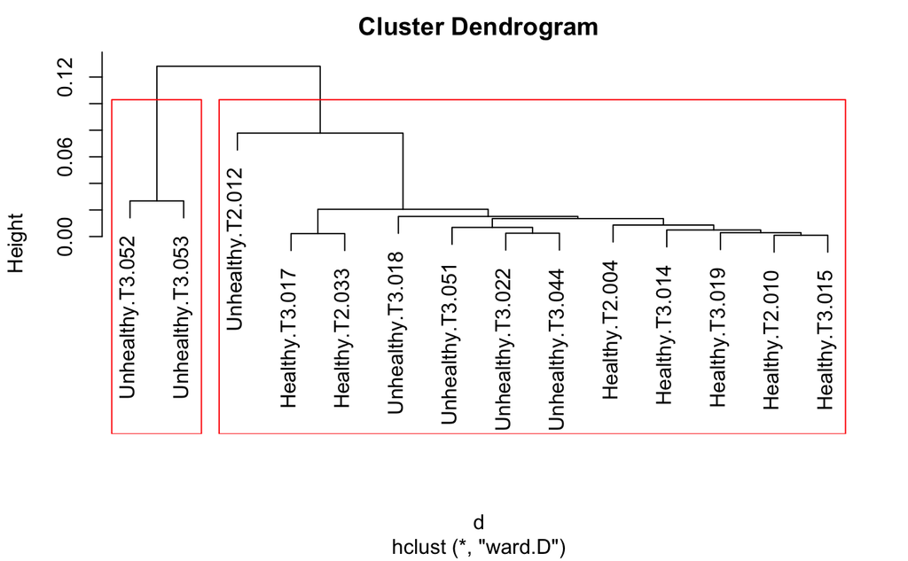

```r
d <- dist(xgb_bacteria, method = "euclidean") # distance matrix
fit <- hclust(d, method="ward.D")
plot(fit) # display dendogram
groups <- cutree(fit, k=2)
rect.hclust(fit, k=2, border="red")
```

Clustering with low p value bacteria:

- I am interested to see if the 3 bacteria with the lowest p values from above will do a better job at clustering

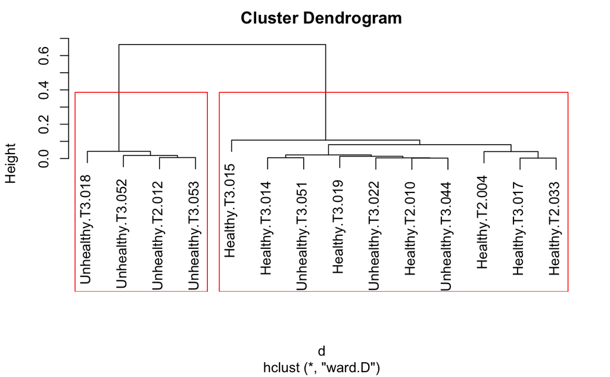

```r
#head(transposed_data)
t_bacteria <- as.matrix(transposed_data[,m[1:3, 1]])
d <- dist(t_bacteria, method = "euclidean") # distance matrix
fit2 <- hclust(d, method="ward.D")
plot(fit2) # display dendogram
groups <- cutree(fit2, k=2)
rect.hclust(fit2, k=2, border="red")
```

- The bacteria with low p values were able to separate our data into a group of 4 unhealthy samples and another group containing the rest of the samples

Conclusion:

Due to our relatively small sample size, we were unable to find bacteria that are powerful indicators of whether or not a patient is healthy. However, we have identified bacteria of interest through t tests and xgboost, which could be interesting to research. The main bacteria of interest are:

- “Streptococcaceae.g_Streptococcus.s_anginosus” (low p value)
- “Lachnospiraceae.g_Blautia.s_wexlerae” (low p value)
- “Lachnospiraceae.g_Dorea.s_formicigenerans” (low p value and important feature)
- “Bacteroidaceae.g_Bacteroides.s_massiliensis” (important feature)

From clustering, we found that the variables with low p values are better at distinguishing healthy from unhealthy samples, so the first 3 bacteria above are likely more significant

```r
test_data<- read.csv("./zymo_test_set.csv")
test_data<- test_data[-1,-c(1, 2, 3, 4, 5)]
dim(test_data)
```

```
[1] 470  13
```

```r
row_names<-apply(test_data, 1, function(r){paste(r[1], r[2], r[3], sep="_")})
rownames(test_data) <- row_names
test_data<- test_data[,-c(1, 2, 3)]
head(test_data)
```

|  | Healthy.T1.Control.Day.28.A024 | Healthy.T1.Control.Day.28.A060 | Healthy.T1.Control.Day.28.A062 | Healthy.T1.Control.Day.28.A030 | Healthy.T1.Control.Day.28.C067 | Healthy.T2.Control.Day.28.A065 | Healthy.T2.Control.Day.28.A066 | Healthy.T2.Control.Day.28.A041 | Healthy.T3.Control.Day.28.A040 | Unhealthy.T1.Control.Day.28.B015 |
| --- | --- | --- | --- | --- | --- | --- | --- | --- | --- | --- |
| Methanobacteriaceae;g_Methanobrevibacter;s_smithii | 0.0000000000 | 0.0000000000 | 0 | 0 | 0.0003282119 | 0.0000000000 | 0.0000000000 | 0 | 0 | 0.0000000000 |
| Methanobacteriaceae;g_Methanosphaera;s_sp792 | 0.0000000000 | 0.0000000000 | 0 | 0 | 0.0000000000 | 0.0000000000 | 0.0000000000 | 0 | 0 | 0.0011630754 |
| Actinomycetaceae;g_Actinomyces;s_graevenitzii | 0.0000000000 | 0.0000000000 | 0 | 0 | 0.0000000000 | 0.0000000000 | 0.0000000000 | 0 | 0 | 0.0000000000 |
| Actinomycetaceae;g_Actinomyces;s_odontolyticus | 0.0004151272 | 0.0002338929 | 0 | 0 | 0.0002666721 | 0.0001411615 | 0.0001977653 | 0 | 0 | 0.0009998368 |
| Actinomycetaceae;g_Actinomyces;s_oris-viscosus | 0.0000000000 | 0.0000000000 | 0 | 0 | 0.0000000000 | 0.0000000000 | 0.0000000000 | 0 | 0 | 0.0000000000 |
| Actinomycetaceae;g_Actinomyces;s_turicensis | 0.0000000000 | 0.0000000000 | 0 | 0 | 0.0000000000 | 0.0000000000 | 0.0000000000 | 0 | 0 | 0.0000000000 |

```r
library(stringr)
s <- c("hello;world", "by;.world")
s<- sapply(s, function(e){as.character(str_replace(e, ";", "."))})
#str_replace("hello;world",";", ".")
s <- as.character(s)
s
```

```
[1] "hello.world" "by..world"
```

```r
row_names<- as.character(row_names)

#transposed_data[, "Methanobacteriaceae;g_Methanobrevibacter;s_smithii"]
#test_data[      "Lachnospiraceae.g_Dorea.s_formicigenerans",]
which(row_names=="Lachnospiraceae;g_Dorea;s_formicigenerans")

test_data[201, ]
```

[output not shown]

```r
row_names <- as.character(sapply(row_names, function(e){str_replace(e, ";", ".")}))
rownames(test_data)<- row_names
head(test_data)
```

|  | Healthy.T1.Control.Day.28.A024 | Healthy.T1.Control.Day.28.A060 | Healthy.T1.Control.Day.28.A062 | Healthy.T1.Control.Day.28.A030 | Healthy.T1.Control.Day.28.C067 | Healthy.T2.Control.Day.28.A065 | Healthy.T2.Control.Day.28.A066 | Healthy.T2.Control.Day.28.A041 | Healthy.T3.Control.Day.28.A040 | Unhealthy.T1.Control.Day.28.B015 |
| --- | --- | --- | --- | --- | --- | --- | --- | --- | --- | --- |
| Methanobacteriaceae.g_Methanobrevibacter.s_smithii | 0.0000000000 | 0.0000000000 | 0 | 0 | 0.0003282119 | 0.0000000000 | 0.0000000000 | 0 | 0 | 0.0000000000 |
| Methanobacteriaceae.g_Methanosphaera.s_sp792 | 0.0000000000 | 0.0000000000 | 0 | 0 | 0.0000000000 | 0.0000000000 | 0.0000000000 | 0 | 0 | 0.0011630754 |
| Actinomycetaceae.g_Actinomyces.s_graevenitzii | 0.0000000000 | 0.0000000000 | 0 | 0 | 0.0000000000 | 0.0000000000 | 0.0000000000 | 0 | 0 | 0.0000000000 |
| Actinomycetaceae.g_Actinomyces.s_odontolyticus | 0.0004151272 | 0.0002338929 | 0 | 0 | 0.0002666721 | 0.0001411615 | 0.0001977653 | 0 | 0 | 0.0009998368 |
| Actinomycetaceae.g_Actinomyces.s_oris-viscosus | 0.0000000000 | 0.0000000000 | 0 | 0 | 0.0000000000 | 0.0000000000 | 0.0000000000 | 0 | 0 | 0.0000000000 |
| Actinomycetaceae.g_Actinomyces.s_turicensis | 0.0000000000 | 0.0000000000 | 0 | 0 | 0.0000000000 | 0.0000000000 | 0.0000000000 | 0 | 0 | 0.0000000000 |

```r
i <- intersect(row_names, colnames(transposed_data))
length(i)
```

```
[1] 254
```

```r
l_names<- c()
for(i in 1:length(row_names)){
  if (startsWith(row_names[i], "L")){
    l_names<- c(l_names, row_names[i])
  }
}
colnames(transposed_data)
```

```r
transposed_test<- data.frame(t(test_data))
full_data<- bind_rows(transposed_data, transposed_test)
full_data
```

|  | Actinomycetaceae.g_Actinomyces.s_odontolyticus | Actinomycetaceae.g_Actinomyces.s_oris | Actinomycetaceae.g_NA.s_sp4816 | Bifidobacteriaceae.g_Bifidobacterium.s_adolescentis.faecale | Bifidobacteriaceae.g_Bifidobacterium.s_animalis | Bifidobacteriaceae.g_Bifidobacterium.s_bifidum | Bifidobacteriaceae.g_Bifidobacterium.s_breve | Bifidobacteriaceae.g_Bifidobacterium.s_catenulatum.kashiwanohense.pseudocatenulatum | Bifidobacteriaceae.g_Bifidobacterium.s_longum | Bifidobacteriaceae.g_Bifidobacterium.s_pseudolongum | Corynebacteriaceae.g_Corynebacterium.s_appendicis | Micrococcaceae.g_Rothia.s_mucilaginosa | Propionibacteriaceae.g_Propionibacterium.s_acnes | Coriobacteriaceae.g_Adlercreutzia.Asaccharobacter.s_celatus.equolifaciens | Coriobacteriaceae.g_Collinsella.s_aerofaciens | Coriobacteriaceae.g_Collinsella.s_intestinalis.stercoris | Coriobacteriaceae.g_Collinsella.s_sp10410 | Coriobacteriaceae.g_Collinsella.s_sp10422 | Coriobacteriaceae.g_Collinsella.s_sp10425 | Coriobacteriaceae.g_Collinsella.s_tanakaei | Coriobacteriaceae.g_Denitrobacterium.s_detoxificans.sp10543 | Coriobacteriaceae.g_Eggerthella.s_lenta | Coriobacteriaceae.g_Eggerthella.s_sinensis | Coriobacteriaceae.g_Enterorhabdus.s_caecimuris | Coriobacteriaceae.g_Enterorhabdus.s_caecimuris.mucosicola | Coriobacteriaceae.g_Gordonibacter.s_faecihominis | Coriobacteriaceae.g_Gordonibacter.s_pamelaeae | Coriobacteriaceae.g_NA.s_sp10501 | Coriobacteriaceae.g_NA.s_sp10534 | … |
| --- | --- | --- | --- | --- | --- | --- | --- | --- | --- | --- | --- | --- | --- | --- | --- | --- | --- | --- | --- | --- | --- | --- | --- | --- | --- | --- | --- | --- | --- | --- |
| Healthy.T2.004 | 0.0001934985 | 0.0000000000 | 0.0000000000 | 0.000000000 | 0.0000000000 | 0.00000000 | 0.0000000000 | 0.000000000 | 0.118154992 | 0.0000000000 | 0.0000000000 | 0.0000000000 | 0.0000000000 | 0.0000000000 | 0.000000000 | 0.00000000 | 0.0000000000 | 0.0000000000 | 0.0000000000 | 0.000000000 | 0.000000000 | 0.0000000000 | 0.0000000000 | 0.0000000000 | 0.000000000 | 0.0003386223 | 0.0000000000 | 0.000000000 | 0.0000000000 | … |
| Healthy.T2.010 | 0.0001854835 | 0.0000000000 | 0.0000000000 | 0.068765559 | 0.0000000000 | 0.00000000 | 0.0000000000 | 0.015033924 | 0.016800898 | 0.0000000000 | 0.0000000000 | 0.0001757212 | 0.0002147703 | 0.0010152780 | 0.040113243 | 0.00000000 | 0.0000000000 | 0.0000000000 | 0.0000000000 | 0.003367989 | 0.000000000 | 0.0000000000 | 0.0000000000 | 0.0003319178 | 0.000000000 | 0.0000000000 | 0.0000000000 | 0.002059843 | 0.0000000000 | … |
| Healthy.T3.014 | 0.0007030958 | 0.0000000000 | 0.0000000000 | 0.000000000 | 0.0000000000 | 0.00000000 | 0.0000000000 | 0.000000000 | 0.011601081 | 0.0000000000 | 0.0003076044 | 0.0002636609 | 0.0000000000 | 0.0000000000 | 0.016676554 | 0.00000000 | 0.0000000000 | 0.0000000000 | 0.0000000000 | 0.000000000 | 0.000000000 | 0.0021971744 | 0.0000000000 | 0.0000000000 | 0.000000000 | 0.0000000000 | 0.0000000000 | 0.000000000 | 0.0000000000 | … |
| Healthy.T3.015 | 0.0000000000 | 0.0000000000 | 0.0000000000 | 0.000000000 | 0.0154626774 | 0.00000000 | 0.0000000000 | 0.000262450 | 0.000000000 | 0.0000000000 | 0.0002405791 | 0.0000000000 | 0.0000000000 | 0.0000000000 | 0.000000000 | 0.00000000 | 0.0000000000 | 0.0000000000 | 0.0000000000 | 0.000000000 | 0.000000000 | 0.0088139448 | 0.0000000000 | 0.0000000000 | 0.000000000 | 0.0000000000 | 0.0000000000 | 0.000000000 | 0.0000000000 | … |
| Healthy.T3.017 | 0.0003603171 | 0.0000000000 | 0.0000000000 | 0.001621427 | 0.0000000000 | 0.02269998 | 0.0000000000 | 0.009098006 | 0.013361758 | 0.0000000000 | 0.0000000000 | 0.0000000000 | 0.0000000000 | 0.0015313476 | 0.039364641 | 0.00000000 | 0.0008407399 | 0.0000000000 | 0.0000000000 | 0.003933461 | 0.000000000 | 0.0003302907 | 0.0000000000 | 0.0000000000 | 0.000000000 | 0.0000000000 | 0.0000000000 | 0.001261110 | 0.0000000000 | … |
| Healthy.T3.019 | 0.0000000000 | 0.0000000000 | 0.0000000000 | 0.001898469 | 0.0000000000 | 0.00000000 | 0.0000000000 | 0.133580483 | 0.097763693 | 0.0000000000 | 0.0000000000 | 0.0000000000 | 0.0000000000 | 0.0000000000 | 0.023035757 | 0.00000000 | 0.0000000000 | 0.0000000000 | 0.0003139201 | 0.000000000 | 0.000000000 | 0.0054711791 | 0.0000000000 | 0.0000000000 | 0.000000000 | 0.0000000000 | 0.0000000000 | 0.000000000 | 0.0000000000 | … |
| Healthy.T2.033 | 0.0004470701 | 0.0003619139 | 0.0001277343 | 0.000000000 | 0.0000000000 | 0.00000000 | 0.0000000000 | 0.000000000 | 0.032827718 | 0.0000000000 | 0.0000000000 | 0.0000000000 | 0.0002128905 | 0.0007876949 | 0.000000000 | 0.06347331 | 0.0000000000 | 0.0000000000 | 0.0000000000 | 0.000000000 | 0.000000000 | 0.0021076162 | 0.0000000000 | 0.0000000000 | 0.000000000 | 0.0000000000 | 0.0003725584 | 0.000000000 | 0.0000000000 | … |
| Unhealthy.T2.012 | 0.0001556178 | 0.0000000000 | 0.0000000000 | 0.000000000 | 0.0000000000 | 0.00000000 | 0.0015302417 | 0.000000000 | 0.045712730 | 0.0000000000 | 0.0000000000 | 0.0000000000 | 0.0000000000 | 0.0000000000 | 0.000000000 | 0.00000000 | 0.0000000000 | 0.0000000000 | 0.0000000000 | 0.000000000 | 0.000000000 | 0.0059394128 | 0.0003242038 | 0.0000000000 | 0.000000000 | 0.0000000000 | 0.0000000000 | 0.000000000 | 0.0000000000 | … |
| Unhealthy.T3.018 | 0.0000000000 | 0.0000000000 | 0.0000000000 | 0.000000000 | 0.0000000000 | 0.00000000 | 0.0000000000 | 0.030687972 | 0.009995320 | 0.0000000000 | 0.0000000000 | 0.0000000000 | 0.0000000000 | 0.0000000000 | 0.014708832 | 0.00000000 | 0.0000000000 | 0.0000000000 | 0.0000000000 | 0.000000000 | 0.000000000 | 0.0026743331 | 0.0000000000 | 0.0000000000 | 0.000000000 | 0.0000000000 | 0.0000000000 | 0.000000000 | 0.0000000000 | … |
| Unhealthy.T3.022 | 0.0000000000 | 0.0000000000 | 0.0000000000 | 0.000000000 | 0.0000000000 | 0.00000000 | 0.0000000000 | 0.000000000 | 0.005488956 | 0.0000000000 | 0.0000000000 | 0.0000000000 | 0.0000000000 | 0.0006147631 | 0.014593305 | 0.00000000 | 0.0000000000 | 0.0000000000 | 0.0000000000 | 0.000000000 | 0.000000000 | 0.0002049210 | 0.0000000000 | 0.0000000000 | 0.000000000 | 0.0000000000 | 0.0004098421 | 0.000000000 | 0.0000000000 | … |

[output cut: 14 more lines]

```r
pos<- c(which(colnames(full_data)=="Lachnospiraceae.g_Dorea.s_formicigenerans"), which(colnames(full_data)=="Streptococcaceae.g_Streptococcus.s_anginosus"), which(colnames(full_data)=="Lachnospiraceae.g_Blautia.s_wexlerae"), which(colnames(full_data)=="Bacteroidaceae.g_Bacteroides.s_massiliensis"))
significant_rows <- full_data[, pos]
significant_rows
```

|  | Lachnospiraceae.g_Dorea.s_formicigenerans | Streptococcaceae.g_Streptococcus.s_anginosus | Lachnospiraceae.g_Blautia.s_wexlerae | Bacteroidaceae.g_Bacteroides.s_massiliensis |
| --- | --- | --- | --- | --- |
| Healthy.T2.004 | 0.000000000 | 0.0001572175 | 0.00000000 | 0.0000000000 |
| Healthy.T2.010 | 0.004656612 | 0.0002245326 | 0.04535559 | 0.0000000000 |
| Healthy.T3.014 | 0.007382506 | 0.0000000000 | 0.05719245 | 0.0000000000 |
| Healthy.T3.015 | 0.005577062 | 0.0000000000 | 0.10780133 | 0.0000000000 |
| Healthy.T3.017 | 0.013662023 | 0.0003603171 | 0.02714389 | 0.0000000000 |
| Healthy.T3.019 | 0.007519134 | 0.0000000000 | 0.03826836 | 0.0000000000 |
| Healthy.T2.033 | 0.012251849 | 0.0002341796 | 0.02932567 | 0.0000000000 |
| Unhealthy.T2.012 | 0.000000000 | 0.0000000000 | 0.17381212 | 0.0000000000 |
| Unhealthy.T3.018 | 0.000000000 | 0.0000000000 | 0.20766196 | 0.0000000000 |
| Unhealthy.T3.022 | 0.003703216 | 0.0000000000 | 0.04953234 | 0.0034982948 |

[output cut: 14 more lines]

```r
healthy_train<- significant_rows[1:7,]
unhealthy_train<- significant_rows[8:14,]
healthy_test<- significant_rows[15:23,]
unhealthy_test<- significant_rows[23,]
```

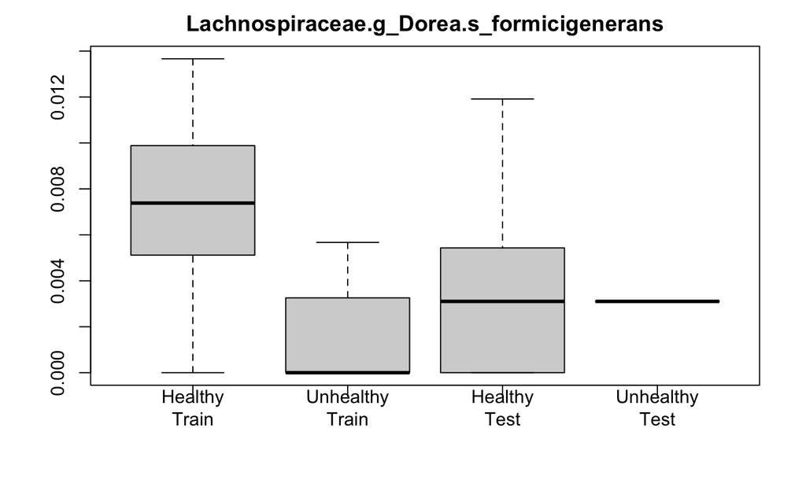

```r
plot_train_and_test <- function(i){
  boxplot(healthy_train[,i], unhealthy_train[,i], healthy_test[,i], unhealthy_test[,i], names=c("Healthy\nTrain", "Unhealthy\nTrain", "Healthy\nTest", "Unhealthy\nTest"), main=colnames(significant_rows)[i])
}
#par(mfrow=c(2, 2))
plot_train_and_test(1)
```

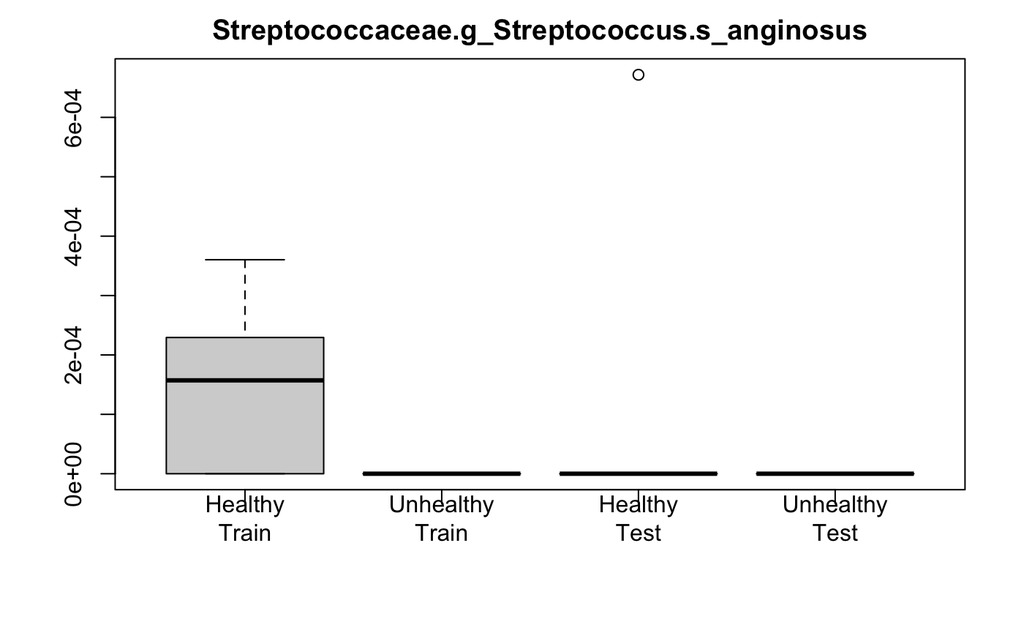

```r
plot_train_and_test(2)
```

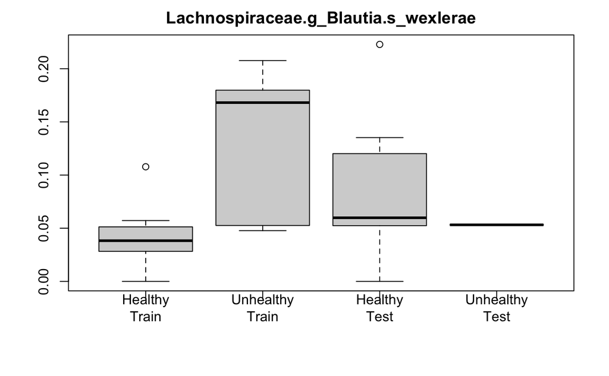

```r
plot_train_and_test(3)
```

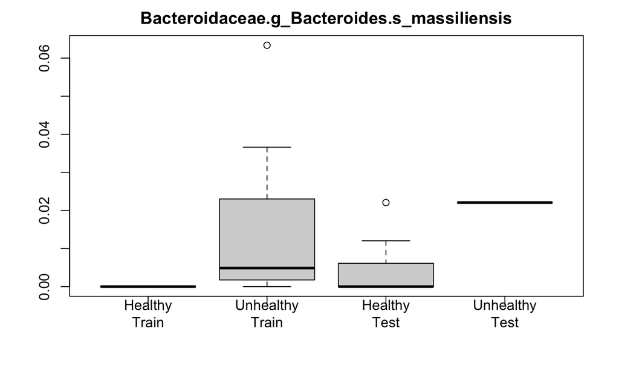

```r
plot_train_and_test(4)
```

[output not shown]